# Convolutional Autoencoders

In this assignment, I used Convolutional Autoencoders to detect anomalies in images of Flowers Recognitionn dataset. This dataset contains 4,242 images of five categories: daisy, dandelion, rose, sunflower and tulip.

The specific tasks are:

1. Created a Convolutional Autoencoders to detect anomalies of the images.
2. Trained Autoencoder on the sunflower images. Output the same examples of the original vs. reconstructed images.
3. Evaluated the Autoencoder to each one of the other flower types to detect anomalies and find the MSE between the normal and anomalous images.
4. Output the sidtribution of density scores among training, validation, and anomalies for each flower type.
5. Explained the how the autoencoder work for anomaly detection.
6. Expalined what other methods can be used instead of anomaly detection.

1). Created a Convolutional Autoencoders

We treated images of sunflower as normal and after training the system using solely images of sunflower.

```python
#import libs
import os
import cv2
import keras
from keras.models import Sequential
from keras.layers import Dense, Activation, Flatten, Input
from keras.layers import Conv2D, MaxPooling2D, UpSampling2D
import matplotlib.pyplot as plt
from keras import backend as K
import numpy as np
from tensorflow.keras.preprocessing.image import ImageDataGenerator, array_to_img, img_to_array, load_img
from tensorflow.keras.preprocessing import image
#from PIL import Image, ImageChops
from sklearn.neighbors import KernelDensity
import random
from sklearn.model_selection import train_test_split
from statistics import mean
```

```
2023-04-04 11:06:05.594773: I tensorflow/core/platform/cpu_feature_guard.cc:193] This TensorFlow binary is optimized with oneAPI Deep Neural Network Library (oneDNN) to use the following CPU instructions in performance-critical operations:  SSE4.1 SSE4.2 AVX AVX2 FMA
To enable them in other operations, rebuild TensorFlow with the appropriate compiler flags.
```

```python
#The command %matplotlib inline is used in Jupyter Notebook or similar environments to display matplotlib plots inline with the code.
#It should be noted that %matplotlib inline only needs to be run once at the beginning of the notebook session to activate this feature.
%matplotlib inline
```

```python
# Define the image size
IMG_SIZE = 96

# Load and preprocess the images
def preprocess_images(DIRECTORY):
    data = []
    for img in os.listdir(DIRECTORY):
        img_array = cv2.imread(os.path.join(DIRECTORY, img))
        img_array = cv2.cvtColor(img_array, cv2.COLOR_BGR2RGB)
        img_array = cv2.resize(img_array, (IMG_SIZE, IMG_SIZE))
        img_array = img_array.astype('float32') / 255.
        data.append(img_array)
    return np.array(data)

# Preprocess the images
sunflower_images = preprocess_images('./flowers/sunflower/')

sunflower_train, sunflower_val = train_test_split(sunflower_images, test_size=0.2, random_state=42)

print("train", sunflower_train.shape)
print("test", sunflower_val.shape)

# Define the input shape of the images
input_img = Input(shape=(96, 96, 3))


# Define the convolutional autoencoder model
# The output layer must be the same dimensions as the original image

sunflower_model = Sequential()

sunflower_model.add(Conv2D(16, (3, 3), padding='same',activation='relu', input_shape=(96, 96, 3)))
sunflower_model.add(MaxPooling2D(pool_size=(4,4), padding='same')) # using pool_size (4,4) makes the layer 4x smaller in height and width

sunflower_model.add(Conv2D(8,(3, 3),activation='relu',  padding='same'))
sunflower_model.add(MaxPooling2D(pool_size=(4,4), padding='same'))

sunflower_model.add(Conv2D(3,(3, 3),activation='relu',  padding='same'))
sunflower_model.add(MaxPooling2D(pool_size=(2,2), padding='same'))

#-------------------------
sunflower_model.add(Conv2D(3,(3, 3),activation='relu',  padding='same'))
sunflower_model.add(UpSampling2D((2, 2)))

sunflower_model.add(Conv2D(8,(3, 3),activation='relu',  padding='same'))
sunflower_model.add(UpSampling2D((4, 4)))

sunflower_model.add(Conv2D(16,(3, 3),activation='relu',  padding='same'))
sunflower_model.add(UpSampling2D((4, 4)))

sunflower_model.add(Conv2D(3,(3, 3), activation='sigmoid', padding='same'))
#-------------------------

# Compile the model
sunflower_model.compile(optimizer='adam', loss='mean_squared_error')
sunflower_model.summary()

#sunflower_model.fit(sunflower_train, sunflower_train, epochs=50, batch_size=128, validation_data=(sunflower_val, sunflower_val))

es = keras.callbacks.EarlyStopping(monitor='val_loss', mode='min', verbose=1, patience=30) # Early stopping (stops training when validation doesn't improve for {patience} epochs)
sunflower_model_filepath = 'models/sunflowermodel.keras'
save_best = keras.callbacks.ModelCheckpoint(sunflower_model_filepath, monitor='val_loss', save_best_only=True, mode='min') # Saves the best version of the model to disk (as measured on the validation data set)
sunflower_model.fit(sunflower_train, sunflower_train,
        #steps_per_epoch=1000,
        epochs=500,
        validation_data=(sunflower_val, sunflower_val),
        #validation_steps=1000,
        shuffle = True,
        callbacks=[es, save_best])
```

```
train (586, 96, 96, 3)
test (147, 96, 96, 3)
Model: "sequential"
_________________________________________________________________
 Layer (type)                Output Shape              Param #
=================================================================
 conv2d (Conv2D)             (None, 96, 96, 16)        448

 max_pooling2d (MaxPooling2D  (None, 24, 24, 16)       0
 )

 conv2d_1 (Conv2D)           (None, 24, 24, 8)         1160

 max_pooling2d_1 (MaxPooling  (None, 6, 6, 8)          0
 2D)

 conv2d_2 (Conv2D)           (None, 6, 6, 3)           219

 max_pooling2d_2 (MaxPooling  (None, 3, 3, 3)          0
 2D)

 conv2d_3 (Conv2D)           (None, 3, 3, 3)           84

 up_sampling2d (UpSampling2D  (None, 6, 6, 3)          0
 )

 conv2d_4 (Conv2D)           (None, 6, 6, 8)           224

 up_sampling2d_1 (UpSampling  (None, 24, 24, 8)        0
 2D)

 conv2d_5 (Conv2D)           (None, 24, 24, 16)        1168

 up_sampling2d_2 (UpSampling  (None, 96, 96, 16)       0
 2D)

 conv2d_6 (Conv2D)           (None, 96, 96, 3)         435

=================================================================
Total params: 3,738
Trainable params: 3,738
Non-trainable params: 0
_________________________________________________________________
```

```
2023-04-04 11:06:09.153703: I tensorflow/core/platform/cpu_feature_guard.cc:193] This TensorFlow binary is optimized with oneAPI Deep Neural Network Library (oneDNN) to use the following CPU instructions in performance-critical operations:  SSE4.1 SSE4.2 AVX AVX2 FMA
To enable them in other operations, rebuild TensorFlow with the appropriate compiler flags.
2023-04-04 11:06:09.154422: I tensorflow/core/common_runtime/process_util.cc:146] Creating new thread pool with default inter op setting: 2. Tune using inter_op_parallelism_threads for best performance.
```

```
<keras.callbacks.History at 0x7f363c43d7f0>
```

2). Trained the Autoencoder on the sunflower images. Output the same examples of the original vs. reconstructed images.

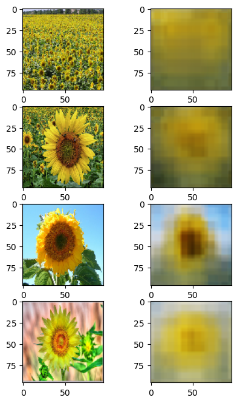

```python
# Training continues after improvement stops for the number of epochs equivalent to the 'patience' hyper-parameter
# To get back the model that performed best on the validation set we load the checkpointed model from disk:
sunflower_model = keras.models.load_model(sunflower_model_filepath)

# Test the model by viewing a sample of original and reconstructed images
sunflower_predict = sunflower_model.predict(sunflower_val)
no_of_samples = 4
_, axs = plt.subplots(no_of_samples, 2, figsize=(5, 8))
axs = axs.flatten()
imgs = []
for i in range(no_of_samples):
    imgs.append(sunflower_val[i])
    imgs.append(sunflower_predict[i])
for img, ax in zip(imgs, axs):
    ax.imshow(img)
plt.show()
```

3). Evaluated Autoencoder

Evaluated Autoencoder to each one of the other flower types to detect anomalies and find the MSE between the normal and anomalous images.

```python
# We build a replica of the first half of the auto-encoder (the encoder only)
# This network takes a an image which is 96x96x3 and compresses it down to a 3x3x3 tensor
encoder_replica = Sequential()
encoder_replica.add(Conv2D(16, (3, 3), padding='same',activation='relu', input_shape=(96, 96, 3), weights=sunflower_model.layers[0].get_weights()) )
encoder_replica.add(MaxPooling2D(pool_size=(4,4), padding='same'))
encoder_replica.add(Conv2D(8,(3, 3),activation='relu',  padding='same', weights=sunflower_model.layers[2].get_weights()))
encoder_replica.add(MaxPooling2D(pool_size=(4,4), padding='same'))
encoder_replica.add(Conv2D(3,(3, 3),activation='relu',  padding='same', weights=sunflower_model.layers[4].get_weights()))
encoder_replica.add(MaxPooling2D(pool_size=(2,2), padding='same'))
encoder_replica.summary()

# Create a function for classifying images in bulk (for testing purposes)
def get_mse(original, reconstruction):
    # Returns the mean square error for each image in the array
    return np.mean((original - reconstruction)**2, axis=(1,2,3))

def evaluate_model(images,flower_type):
    density_threshold = 0 # This threshold was chosen based on looking at the distribution of the density scores of the normal class (validation set)
    reconstruction_error_threshold = 0.04  # This threshold was chosen based on looking at the distribution of reconstruction errors of the normal class

    reconstructions = sunflower_model.predict(images)
    MSEs = get_mse(images, reconstructions)
    reconstruction_anomalies = MSEs > reconstruction_error_threshold
    print(f'Reconstruction anomalies = {sum(reconstruction_anomalies)}')
    print(f'MSE between the normal and anomalous images {flower_type} = {mean(MSEs)}' )

    encoded_images = encoder_replica.predict(images)
    encoded_images_flat = np.array([np.reshape(img, (27)) for img in encoded_images])
    kde = KernelDensity(kernel='gaussian', bandwidth=0.2).fit(encoded_images_flat)
    density_scores = kde.score_samples(encoded_images_flat)
    density_anomalies = density_scores < density_threshold

    combined_anomalies = np.maximum(reconstruction_anomalies, density_anomalies)
    print(f'Combined anomalies = {sum(combined_anomalies)}')
    overall_detection_rate = sum(combined_anomalies) / len(combined_anomalies)
    print(f'Overall detection rate = {overall_detection_rate}')
```

```
Model: "sequential_1"
_________________________________________________________________
 Layer (type)                Output Shape              Param #
=================================================================
 conv2d_7 (Conv2D)           (None, 96, 96, 16)        448

 max_pooling2d_3 (MaxPooling  (None, 24, 24, 16)       0
 2D)

 conv2d_8 (Conv2D)           (None, 24, 24, 8)         1160

 max_pooling2d_4 (MaxPooling  (None, 6, 6, 8)          0
 2D)

 conv2d_9 (Conv2D)           (None, 6, 6, 3)           219

 max_pooling2d_5 (MaxPooling  (None, 3, 3, 3)          0
 2D)

=================================================================
Total params: 1,827
Trainable params: 1,827
Non-trainable params: 0
_________________________________________________________________
```

(1)Evaluated Autoencoder to daisy to detct anomalies and find the MSE between the normal and anomalous images.

```python
# Preprocess the images
daisy_images = preprocess_images('./flowers/daisy/')
# Check what proportion of daisy get classed as anomalous
evaluate_model(daisy_images,'daisy')
```

```
Reconstruction anomalies = 456
MSE between the normal and anomalous images daisy = 0.04898378625512123
Combined anomalies = 456
Overall detection rate = 0.5968586387434555
```

(2)Evaluated Autoencoder to dandelion to detct anomalies and find the MSE between the normal and anomalous images.

```python
# Preprocess the images
dandelion_images = preprocess_images('./flowers/dandelion/')
# Check what proportion of dandelion get classed as anomalous
evaluate_model(dandelion_images,'dandelion')
```

```
Reconstruction anomalies = 200
MSE between the normal and anomalous images dandelion = 0.029514674097299576
Combined anomalies = 200
Overall detection rate = 0.19011406844106463
```

(3)Evaluated Autoencoder to rose to detct anomalies and find the MSE between the normal and anomalous images.

```python
# Preprocess the images
rose_images = preprocess_images('./flowers/rose/')
# Check what proportion of rose get classed as anomalous
evaluate_model(rose_images,'rose')
```

```
Reconstruction anomalies = 434
MSE between the normal and anomalous images rose = 0.0453527495265007
Combined anomalies = 434
Overall detection rate = 0.5535714285714286
```

(4)Evaluated Autoencoder to tulip to detct anomalies and find the MSE between the normal and anomalous images.

```python
# Preprocess the images
tulip_images = preprocess_images('./flowers/tulip/')
# Check what proportion of tulip get classed as anomalous
evaluate_model(tulip_images,'tulip')
```

```
Reconstruction anomalies = 596
MSE between the normal and anomalous images tulip = 0.0459308885037899
Combined anomalies = 596
Overall detection rate = 0.6056910569105691
```

(5) Evaluated Autoencoder to sunflower to detct anomalies and find the MSE between the normal and anomalous images.

```python
# Check what proportion of sunflower get classed as anomalous
evaluate_model(sunflower_images,'sunflower')
```

```
Reconstruction anomalies = 320
MSE between the normal and anomalous images sunflower = 0.03942512720823288
Combined anomalies = 320
Overall detection rate = 0.43656207366984995
```

4). Output the distribution of density scores among training, validation, and anomalies for each flower type

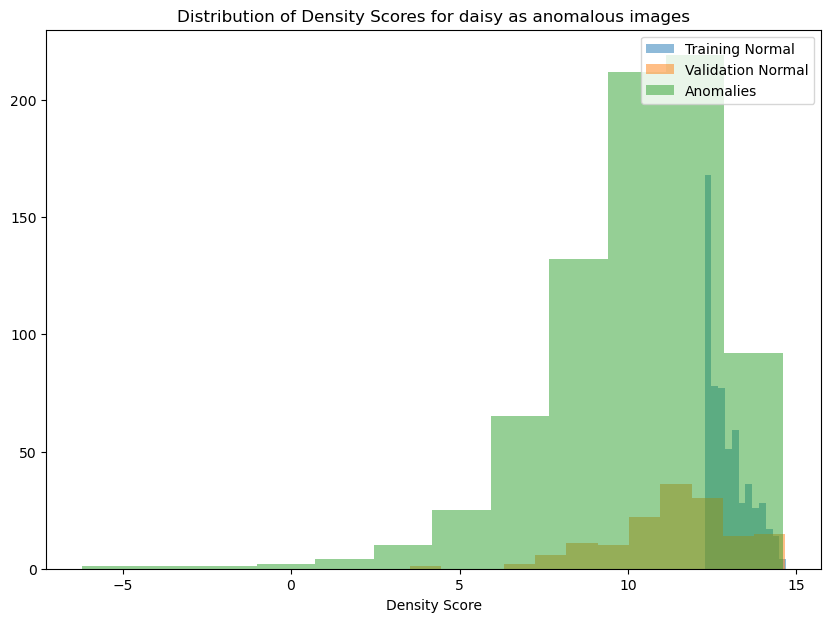

```python
# Creating encoded (compressed versions of the training, validation and anomalous images) and getting their density
# The SKLearn kernel density function only works with 1D arrays so we need to flatten the tensors created by the encoder
encoded_images = encoder_replica.predict(sunflower_train)
encoded_images_flat = [np.reshape(img, (27)) for img in encoded_images]

validation_encoded = encoder_replica.predict(sunflower_val)
val_enc_flat = [np.reshape(img, (27)) for img in validation_encoded]

anom_encoded = encoder_replica.predict(daisy_images)
anom_enc_flat = [np.reshape(img, (27)) for img in anom_encoded]

# Kernel Density Estimation of the encoded vectors
kde = KernelDensity(kernel='gaussian', bandwidth=0.2).fit(encoded_images_flat)
training_density_scores = kde.score_samples(encoded_images_flat)
validation_density_scores = kde.score_samples(val_enc_flat)
anomaly_density_scores = kde.score_samples(anom_enc_flat)

# Plotting the density distributions of the training (normal), validation (normal) and anomalous images
# Ideally we want to see high separation between the normal and anomalous classes
plt.figure(figsize = (10,7))
plt.title('Distribution of Density Scores for daisy as anomalous images')
plt.hist(training_density_scores, 12, alpha=0.5, label='Training Normal')
plt.hist(validation_density_scores, 12, alpha=0.5, label='Validation Normal')
plt.hist(anomaly_density_scores, 12, alpha=0.5, label='Anomalies')
plt.legend(loc='upper right')
plt.xlabel('Density Score')

plt.show()
```

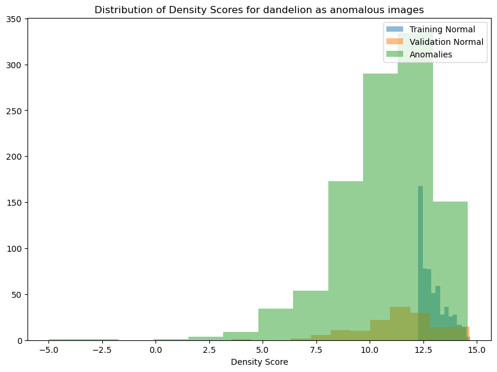

```python
# Creating encoded (compressed versions of the training, validation and anomalous images) and getting their density
# The SKLearn kernel density function only works with 1D arrays so we need to flatten the tensors created by the encoder
encoded_images = encoder_replica.predict(sunflower_train)
encoded_images_flat = [np.reshape(img, (27)) for img in encoded_images]

validation_encoded = encoder_replica.predict(sunflower_val)
val_enc_flat = [np.reshape(img, (27)) for img in validation_encoded]

anom_encoded = encoder_replica.predict(dandelion_images)
anom_enc_flat = [np.reshape(img, (27)) for img in anom_encoded]

# Kernel Density Estimation of the encoded vectors
kde = KernelDensity(kernel='gaussian', bandwidth=0.2).fit(encoded_images_flat)
training_density_scores = kde.score_samples(encoded_images_flat)
validation_density_scores = kde.score_samples(val_enc_flat)
anomaly_density_scores = kde.score_samples(anom_enc_flat)

# Plotting the density distributions of the training (normal), validation (normal) and anomalous images
# Ideally we want to see high separation between the normal and anomalous classes
plt.figure(figsize = (10,7))
plt.title('Distribution of Density Scores for dandelion as anomalous images')
plt.hist(training_density_scores, 12, alpha=0.5, label='Training Normal')
plt.hist(validation_density_scores, 12, alpha=0.5, label='Validation Normal')
plt.hist(anomaly_density_scores, 12, alpha=0.5, label='Anomalies')
plt.legend(loc='upper right')
plt.xlabel('Density Score')

plt.show()
```

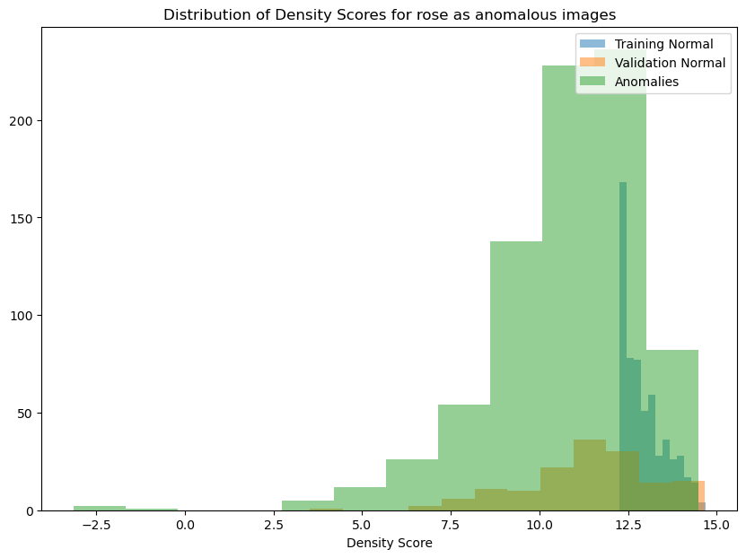

```python
# Creating encoded (compressed versions of the training, validation and anomalous images) and getting their density
# The SKLearn kernel density function only works with 1D arrays so we need to flatten the tensors created by the encoder
encoded_images = encoder_replica.predict(sunflower_train)
encoded_images_flat = [np.reshape(img, (27)) for img in encoded_images]

validation_encoded = encoder_replica.predict(sunflower_val)
val_enc_flat = [np.reshape(img, (27)) for img in validation_encoded]

anom_encoded = encoder_replica.predict(rose_images)
anom_enc_flat = [np.reshape(img, (27)) for img in anom_encoded]

# Kernel Density Estimation of the encoded vectors
kde = KernelDensity(kernel='gaussian', bandwidth=0.2).fit(encoded_images_flat)
training_density_scores = kde.score_samples(encoded_images_flat)
validation_density_scores = kde.score_samples(val_enc_flat)
anomaly_density_scores = kde.score_samples(anom_enc_flat)

# Plotting the density distributions of the training (normal), validation (normal) and anomalous images
# Ideally we want to see high separation between the normal and anomalous classes
plt.figure(figsize = (10,7))
plt.title('Distribution of Density Scores for rose as anomalous images')
plt.hist(training_density_scores, 12, alpha=0.5, label='Training Normal')
plt.hist(validation_density_scores, 12, alpha=0.5, label='Validation Normal')
plt.hist(anomaly_density_scores, 12, alpha=0.5, label='Anomalies')
plt.legend(loc='upper right')
plt.xlabel('Density Score')

plt.show()
```

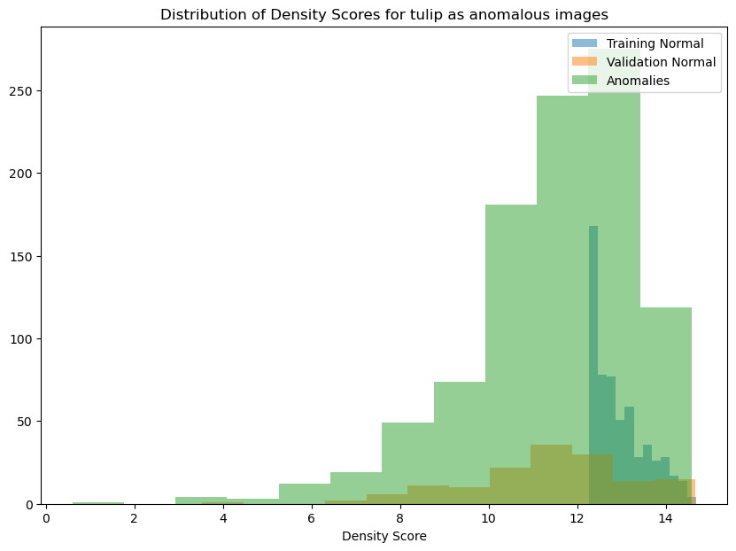

```python
# Creating encoded (compressed versions of the training, validation and anomalous images) and getting their density
# The SKLearn kernel density function only works with 1D arrays so we need to flatten the tensors created by the encoder
encoded_images = encoder_replica.predict(sunflower_train)
encoded_images_flat = [np.reshape(img, (27)) for img in encoded_images]

validation_encoded = encoder_replica.predict(sunflower_val)
val_enc_flat = [np.reshape(img, (27)) for img in validation_encoded]

anom_encoded = encoder_replica.predict(tulip_images)
anom_enc_flat = [np.reshape(img, (27)) for img in anom_encoded]

# Kernel Density Estimation of the encoded vectors
kde = KernelDensity(kernel='gaussian', bandwidth=0.2).fit(encoded_images_flat)
training_density_scores = kde.score_samples(encoded_images_flat)
validation_density_scores = kde.score_samples(val_enc_flat)
anomaly_density_scores = kde.score_samples(anom_enc_flat)

# Plotting the density distributions of the training (normal), validation (normal) and anomalous images
# Ideally we want to see high separation between the normal and anomalous classes
plt.figure(figsize = (10,7))
plt.title('Distribution of Density Scores for tulip as anomalous images')
plt.hist(training_density_scores, 12, alpha=0.5, label='Training Normal')
plt.hist(validation_density_scores, 12, alpha=0.5, label='Validation Normal')
plt.hist(anomaly_density_scores, 12, alpha=0.5, label='Anomalies')
plt.legend(loc='upper right')
plt.xlabel('Density Score')

plt.show()
```

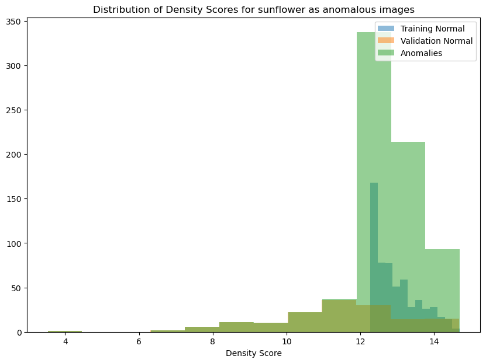

```python
# Creating encoded (compressed versions of the training, validation and anomalous images) and getting their density
# The SKLearn kernel density function only works with 1D arrays so we need to flatten the tensors created by the encoder
encoded_images = encoder_replica.predict(sunflower_train)
encoded_images_flat = [np.reshape(img, (27)) for img in encoded_images]

validation_encoded = encoder_replica.predict(sunflower_val)
val_enc_flat = [np.reshape(img, (27)) for img in validation_encoded]

anom_encoded = encoder_replica.predict(sunflower_images)
anom_enc_flat = [np.reshape(img, (27)) for img in anom_encoded]

# Kernel Density Estimation of the encoded vectors
kde = KernelDensity(kernel='gaussian', bandwidth=0.2).fit(encoded_images_flat)
training_density_scores = kde.score_samples(encoded_images_flat)
validation_density_scores = kde.score_samples(val_enc_flat)
anomaly_density_scores = kde.score_samples(anom_enc_flat)

# Plotting the density distributions of the training (normal), validation (normal) and anomalous images
# Ideally we want to see high separation between the normal and anomalous classes
plt.figure(figsize = (10,7))
plt.title('Distribution of Density Scores for sunflower as anomalous images')
plt.hist(training_density_scores, 12, alpha=0.5, label='Training Normal')
plt.hist(validation_density_scores, 12, alpha=0.5, label='Validation Normal')
plt.hist(anomaly_density_scores, 12, alpha=0.5, label='Anomalies')
plt.legend(loc='upper right')
plt.xlabel('Density Score')

plt.show()
```

5). Explained the how the autoencoder work for anomaly detection.

Autoencoder is a neural network that is trained on a dataset of normal data points, learns a compressed representation of the input data, and then reconstructs it back from the compressed epresentation.

During the training phase, the network minimizes the reconstruction error between the input and output data points. Once the autoencoder is trained, it can be used for anomaly detection by computing the reconstruction error between the original input and the reconstructed output.

Data points with high reconstruction error are likely to be anomalous.

Autoencoder-based anomaly detection is useful in situations where labeled training data is not available and can be used to detect anomalies in high-dimensional data.

6). Expalined what other methods can be used instead of anomaly detection.

Other methods for anomaly detection include statistical methods, clustering methods, Support Vector Machines (SVM), Isolation Forest, and Deep Learning methods such as Convolutional Neural Networks (CNNs) and Recurrent Neural Networks (RNNs).

Statistical methods use statistical properties of the data to identify anomalous data points.

Clustering methods identify anomalous data points that do not belong to any of the clusters or belong to small or sparse clusters.

SVM is a supervised machine learning method that can be used for anomaly detection.

Isolation Forest is an unsupervised machine learning method that randomly partitions the data into subsets to isolate anomalous data points.

Deep Learning methods can learn the patterns and features in the data to identify anomalous data points.

The choice of method depends on the data type, availability of labeled data, and required accuracy and efficiency of the anomaly detection system.